# Doing Data Science Case Study 2

Ashwin Thota and Kevin OKiah

August 2, 2017

## Question 01 (10 points)

Create the X matrix and print it from SAS, R, and Python.

$$\mathbf{X} =\left(\begin{array}{cc}
4 &5 &1 &2\\
1 &1 &4 &5\\
2 &1 &0 &2\\
\end{array}\right)$$

#### R code

```r
X = matrix(c(4,5,1,2, 1,1,4,5,2,1,0,2),
           nrow = 3,
           ncol =4,
           byrow =TRUE)

print(X)
```

```
##      [,1] [,2] [,3] [,4]
## [1,]    4    5    1    2
## [2,]    1    1    4    5
## [3,]    2    1    0    2
```

#### Python Code

```python
import numpy
x = numpy.matrix('4,5,1,2; 1,1,4,5;2,1,0,2')

print(x)
```

```
## [[4 5 1 2]
##  [1 1 4 5]
##  [2 1 0 2]]
```

# Question 02 (15 points)

Please watch videos1 and 2 in week 11 lecture assignment. You can download the code which used for S&P from files tab.

Please do the following with your assigned stock.

- Download the data.
- Calculate log returns.
- Calculate volatility measure.
- Calculate volatility over entire length of series for various three different decay factors.
- Plot the results, overlaying the volatility curves on the data, just as was done in the S&P example.

`Ashwin and Kevin`->XOM

If you cannot download data from your assigned stock you can pick a different stock from the following list. `PM, PG, HON, URTY, PEN`

You can use Yahoo finance or google finance to find your data! Submit your final code and the plot.

# Question 03 (20 points)

The built-in data set called Orange in R is about the growth of orange trees. The Orange data frame has 3 columns of records of the growth of orange trees.

Variable description Tree : an ordered factor indicating the tree on which the measurement is made. The ordering is according to increasing maximum diameter.

age : a numeric vector giving the age of the tree (days since 1968/12/31) circumference : a numeric vector of trunk circumferences (mm). This is probably  
âcircumference at breast heightâ, a standard measurement in forestry.

```r
#Check the structure of the dataset
str(Orange)
```

```
## Classes 'nfnGroupedData', 'nfGroupedData', 'groupedData' and 'data.frame':   35 obs. of  3 variables:
##  $ Tree         : Ord.factor w/ 5 levels "3"<"1"<"5"<"2"<..: 2 2 2 2 2 2 2 4 4 4 ...
##  $ age          : num  118 484 664 1004 1231 ...
##  $ circumference: num  30 58 87 115 120 142 145 33 69 111 ...
##  - attr(*, "formula")=Class 'formula'  language circumference ~ age | Tree
##   .. ..- attr(*, ".Environment")=<environment: R_EmptyEnv>
##  - attr(*, "labels")=List of 2
##   ..$ x: chr "Time since December 31, 1968"
##   ..$ y: chr "Trunk circumference"
##  - attr(*, "units")=List of 2
##   ..$ x: chr "(days)"
##   ..$ y: chr "(mm)"
```

```r
names(Orange)
```

```
## [1] "Tree"          "age"           "circumference"
```

```r
head(Orange)
```

```
##   Tree  age circumference
## 1    1  118            30
## 2    1  484            58
## 3    1  664            87
## 4    1 1004           115
## 5    1 1231           120
## 6    1 1372           142
```

1. Calculate the mean and the median of the trunk circumferences for different size of the trees. (Tree)

```r
pacman::p_load(pacman, dplyr) #load required packages

suppressMessages(
  Summary_<-Orange%>%
  group_by(Tree)%>%
  select(circumference)%>%
  summarise(
    Mean = mean(circumference),
    Median = median(circumference)
  )
)
Summary_
```

```
## # A tibble: 5 × 3
##    Tree      Mean Median
##   <ord>     <dbl>  <dbl>
## 1     3  94.00000    108
## 2     1  99.57143    115
## 3     5 111.14286    125
## 4     2 135.28571    156
## 5     4 139.28571    167
```

2. Make a scatter plot of the trunk circumferences against the age of the tree. Use different plotting symbols for different size of trees.

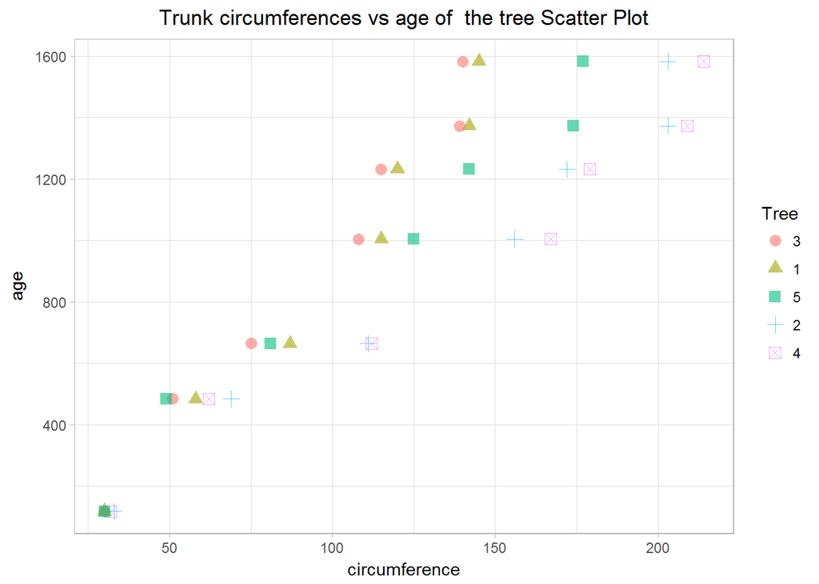

```r
pacman::p_load(ggplot2)#load ggplot2

# Set shape by Tree
ggplot(Orange, aes(x=circumference, y=age, shape=Tree , color=Tree)) + geom_point(size=3, alpha=0.6)+
labs(title="Trunk circumferences vs age of  the tree Scatter Plot")+ theme_light()+theme(plot.title = element_text(hjust = 0.5))
```

3. Display the trunk circumferences on a comparative boxplot against tree. Be sure you order the boxplots in the increasing order of maximum diameter.

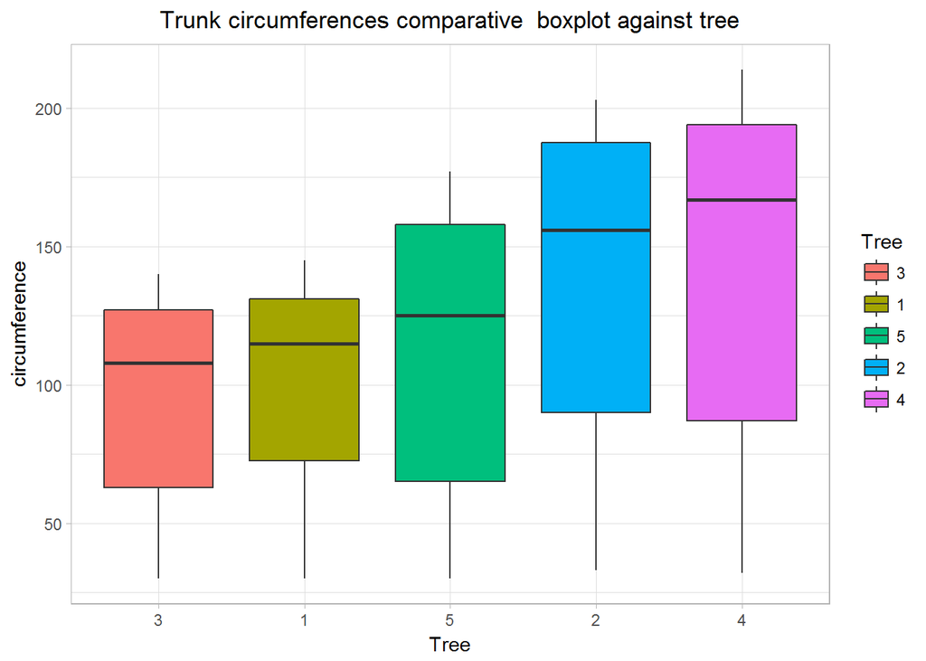

```r
ggplot(data = Orange,aes(y = circumference, x = Tree, fill=Tree)) + geom_boxplot() +
labs(title="Trunk circumferences comparative  boxplot against tree")+ theme_light()+theme(plot.title = element_text(hjust = 0.5))
```

# Question 04 (40 points)

Download âTempâ data set.

```r
Temp<-data.frame((read.csv('TEMP.csv')))

#Format the Date columns to be uniform for easy subsetting
first<-data.frame(as.Date(Temp$Date[1:741]))
names(first)<-c('Formated_Date')
second<-data.frame(as.Date(Temp$Date[742:length(Temp$Date)], format = "%d/%m/%Y"))
names(second)<-c('Formated_Date')

#Add the formated date as a new column in Temp dataset
Temp$Formated_Date =rbind(first, second)
```

1. Find the difference between the maximum and the minimum monthly average temperatures for each country and report/visualize top 20 countries with the maximum differences for the period since 1900.

```r
# subset data with start date >1900
New_Temp<-na.omit(Temp[which(Temp$Formated_Date>='1900/1/1'),])

#using dplyr pipees calculate the Min, Max and difference in average Temp per country
Temp_summary<-New_Temp%>%
  group_by(Country)%>%
  select(Monthly.AverageTemp)%>%
  summarise(
    MAX = max(Monthly.AverageTemp),
    MIN = min(Monthly.AverageTemp),
    Diff = MAX-MIN
  )
#order by difference in decreasing order
newdata <- Temp_summary[order(-Temp_summary$Diff),]
# print top 20 difference
head(newdata, 20)
```

```
## # A tibble: 20 × 4
##         Country    MAX     MIN   Diff
##          <fctr>  <dbl>   <dbl>  <dbl>
## 1    Kazakhstan 25.562 -23.601 49.163
## 2      Mongolia 20.716 -27.294 48.010
## 3        Russia 16.893 -29.789 46.682
## 4        Canada 14.796 -28.736 43.532
## 5    Uzbekistan 30.375 -12.323 42.698
## 6  Turkmenistan 32.136  -8.443 40.579
## 7       Belarus 22.811 -16.527 39.338
## 8       Finland 18.967 -20.101 39.068
## 9       Estonia 22.332 -16.483 38.815
## 10      Ukraine 23.936 -14.724 38.660
## 11   Kyrgyzstan 19.275 -19.161 38.436
## 12  North Korea 23.952 -14.390 38.342
## 13       Latvia 22.279 -15.784 38.063
## 14      Moldova 25.231 -12.781 38.012
## 15    Greenland  0.339 -37.177 37.516
## 16      Denmark  0.699 -36.439 37.138
## 17    Lithuania 21.791 -15.179 36.970
## 18   Tajikistan 19.363 -16.466 35.829
## 19       Poland 22.509 -13.107 35.616
## 20      Armenia 25.291  -9.982 35.273
```

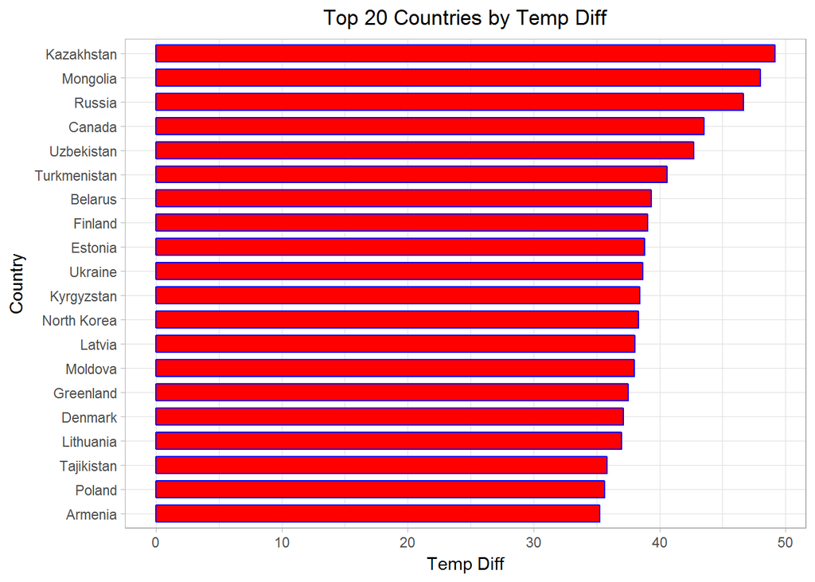

```r
#plotting the data
TempN<-head(newdata, 20)
#plot bar char for the top 20 City Temps
i<-ggplot(data=TempN, aes(y=Diff, reorder(Country, Diff))) +
  geom_bar(stat="identity", color="blue", fill="red",width=.7)+ theme(axis.text.x = element_text(angle = 90, hjust = 1))+labs(title="Top 20 Countries by Temp Diff", y="Temp Diff", x = "Country")+ coord_flip()+ theme_light()+theme(plot.title = element_text(hjust = 0.5))
i
```

```r
# create a new dataframe call UStemp which is a subset of Temp and drop all rows with NAs
UStemp<-na.omit(Temp[which(Temp$Formated_Date>='1900/1/1'),])
```

1. Create a new column to display the monthly average land temperatures in Fahrenheit (Â°F).

```r
#Create and new column called Fahrenheit in UStemp dataset.
UStemp$Fahrenheit<-(UStemp$Monthly.AverageTemp*(180/100))+32 #create a fahrenheit

#print first 6 rows
head(UStemp)
```

```
##         Date Monthly.AverageTemp Monthly.AverageTemp.Uncertainty
## 742 1/1/1900              -3.428                           0.936
## 743 2/1/1900               1.234                           1.135
## 744 3/1/1900              10.545                           0.933
## 745 4/1/1900              13.352                           0.536
## 746 5/1/1900              20.260                           0.524
## 747 6/1/1900              24.448                           0.944
##         Country Formated_Date Fahrenheit
## 742 Afghanistan    1900-01-01    25.8296
## 743 Afghanistan    1900-01-02    34.2212
## 744 Afghanistan    1900-01-03    50.9810
## 745 Afghanistan    1900-01-04    56.0336
## 746 Afghanistan    1900-01-05    68.4680
## 747 Afghanistan    1900-01-06    76.0064
```

2. Calculate average land temperature by year and plot it. The original file has the average land temperature by month.

```r
UStemp<-(Temp[which(Temp$Formated_Date>='1900/1/1'),])# raw data

# create a new Year column based Year a derivative from the Formated_Date column
Year<-format((UStemp$Formated_Date), format = "%Y")
names(Year)<-c('Year') #rename the Year column

#Add the year column to the UStemp dataframe
UStemp<-cbind(UStemp,Year)

UStemp<-na.omit(UStemp) #Omit Nas

#Using dplyr pipes calculated Yearly Land Temp based on the Year column created
Yearly_Land_Avg<-UStemp%>%
  group_by(Year)%>%
  select(Monthly.AverageTemp)%>%
  summarise(
    avg = mean(as.numeric(Monthly.AverageTemp)))
Yearly_Land_Avg
```

```
## # A tibble: 114 × 2
##          Year      avg
##    <S3: AsIs>    <dbl>
## 1        1900 18.57393
## 2        1901 18.54531
## 3        1902 18.39099
## 4        1903 18.48791
## 5        1904 18.26810
## 6        1905 18.45356
## 7        1906 18.53389
## 8        1907 18.19317
## 9        1908 18.34625
## 10       1909 18.40127
## # ... with 104 more rows
```

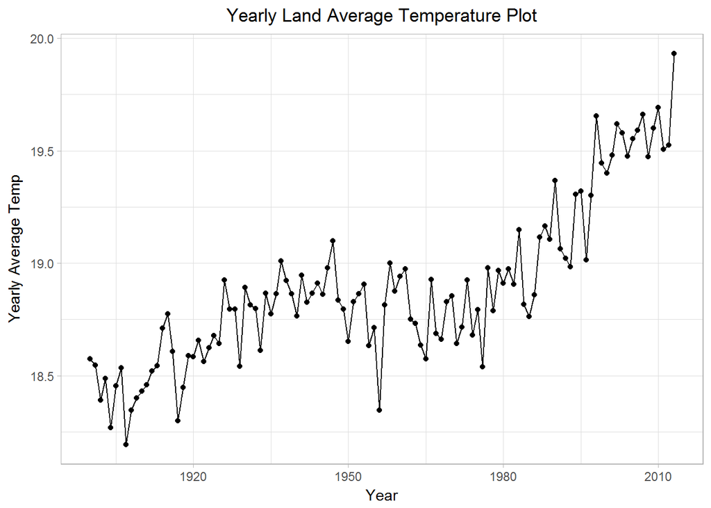

```r
# Plot timeplot of the Yearly_land Temp averages
ggplot(Yearly_Land_Avg, aes(x=as.numeric(Year), y=as.numeric(avg))) +geom_line()+geom_point() +labs(title="Yearly Land Average Temperature Plot", y = 'Yearly Average Temp', x = 'Year')+ theme_light()+theme(plot.title = element_text(hjust = 0.5))
```

3. Calculate the one year difference of average land temperature by year and provide the maximum difference (value) with corresponding years. (for example, year 2000: add all 12 monthly averages and divide by 12 to get average temperature in 2000. You can do the same thing for all the available years. Then you can calculate the one year difference as 1991-1990, 1992-1991, etc)

```r
new<-transform(Yearly_Land_Avg, One_Year_Difference = ave(avg, FUN = function(x) c(NA, diff(x))))

#print first 6 rows to confirm calculations
head(new)
```

```
##   Year      avg One_Year_Difference
## 1 1900 18.57393                  NA
## 2 1901 18.54531         -0.02861817
## 3 1902 18.39099         -0.15431941
## 4 1903 18.48791          0.09691749
## 5 1904 18.26810         -0.21981067
## 6 1905 18.45356          0.18546757
```

```r
#order by difference in decreasing order
newdata <- new[order(-new$One_Year_Difference),]
# print top 20 difference

print('The max difference')
```

```
## [1] "The max difference"
```

```r
head(newdata, 1)
```

```
##    Year      avg One_Year_Difference
## 58 1957 18.81424           0.4675591
```

```r
Y = head(newdata, 1)

print(paste(' The one Year Max difference is' , round(Y$One_Year_Difference, 4),'and the corresponding Years are', Y$Year, '-', (as.numeric(Y$Year)-1)))
```

```
## [1] " The one Year Max difference is 0.4676 and the corresponding Years are 1957 - 1956"
```

3. Download âCityTempâ data set (check your SMU email). Find the difference between the maximum and the minimum temperatures for each major city and report/visualize top 20 cities with maximum differences for the period since 1900.

```r
# Format the date column
CityTemp<-read.csv('CityTemp.csv')
first1<-data.frame(as.Date(CityTemp$Date[1:600]))
names(first1)<-c('Formated_Date')
second1<-data.frame(as.Date(CityTemp$Date[601:length(CityTemp$Date)], format = "%d/%m/%Y"))
names(second1)<-c('Formated_Date')

# add the formated data column to the CityTemp dataframe
CityTemp$Formated_Date =(rbind(first1, second1))

# subset data with start date >1900
New_CityTemp<-na.omit(CityTemp[which(CityTemp$Formated_Date>='1900/1/1'),])

#Group the data by Country and City
City_Temp<-New_CityTemp%>%
  group_by(Country,City)

# caluculate the difference between min and max by city average temp
CityTemp_summary = select(City_Temp,Monthly.AverageTemp)%>%
  summarise(MAX = max(Monthly.AverageTemp),
            MIN = min(Monthly.AverageTemp),
            Diff = MAX-MIN)
#order by difference in decreasing order
City_Temp_Summary_sort <- CityTemp_summary[order(-CityTemp_summary$Diff),]
# print top 20 diff

#print the top 20 Differences from the sorted City Temp data
head(City_Temp_Summary_sort, 20)
```

```
## Source: local data frame [20 x 5]
## Groups: Country [9]
##
##          Country             City    MAX     MIN   Diff
##           <fctr>           <fctr>  <dbl>   <dbl>  <dbl>
## 1          China           Harbin 26.509 -26.772 53.281
## 2          China        Changchun 26.572 -23.272 49.844
## 3         Russia           Moscow 24.580 -19.376 43.956
## 4          China         Shenyang 26.010 -17.035 43.045
## 5         Canada         Montreal 23.059 -18.363 41.422
## 6        Ukraine             Kiev 24.593 -16.191 40.784
## 7         Russia Saint Petersburg 21.921 -18.589 40.510
## 8         Canada          Toronto 23.181 -15.502 38.683
## 9          China          Taiyuan 24.718 -13.116 37.834
## 10         China           Peking 28.936  -8.017 36.953
## 11         China          Tianjin 28.936  -8.017 36.953
## 12   South Korea            Seoul 26.791  -8.992 35.783
## 13          Iran          Mashhad 27.226  -8.384 35.610
## 14         China           Dalian 25.875  -9.348 35.223
## 15 United States          Chicago 26.372  -8.590 34.962
## 16         China         Tangshan 27.346  -7.487 34.833
## 17 United States         New York 25.313  -9.147 34.460
## 18          Iraq          Baghdad 38.283   4.236 34.047
## 19       Germany           Berlin 23.795 -10.125 33.920
## 20         China            Jinan 28.389  -5.389 33.778
```

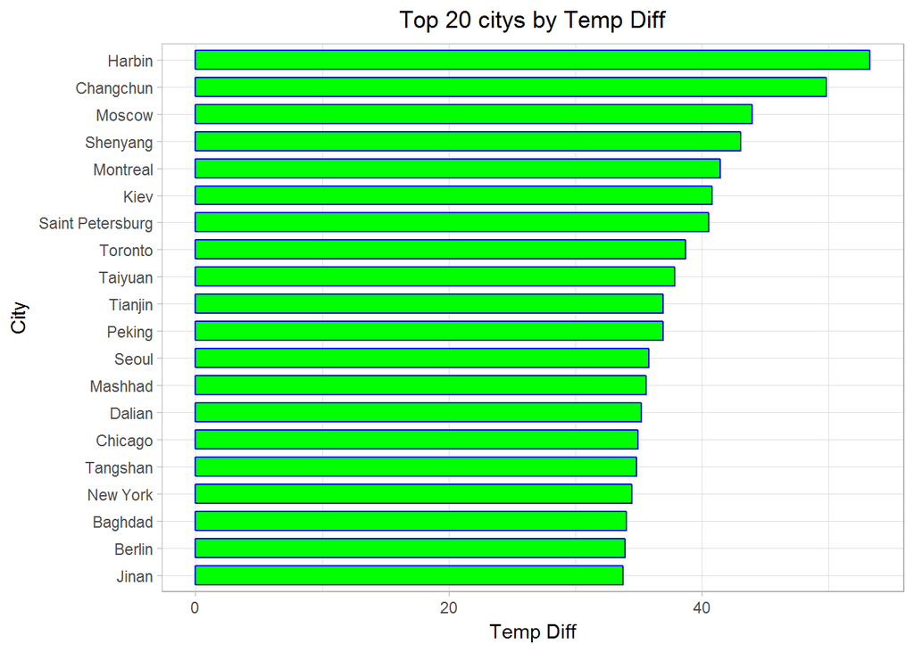

```r
#plotting the data
CDAT<-head(City_Temp_Summary_sort, 20)
#plot bar char for the top 20 City Temps
iii<-ggplot(data=CDAT, aes(y=Diff, reorder(City, Diff))) +
  geom_bar(stat="identity", color="blue", fill="green",width=.7)+ theme(axis.text.x = element_text(angle = 90, hjust = 1))+labs(title="Top 20 citys by Temp Diff", y="Temp Diff", x = "City")+ coord_flip()+ theme_light()+theme(plot.title = element_text(hjust = 0.5))

iii
```

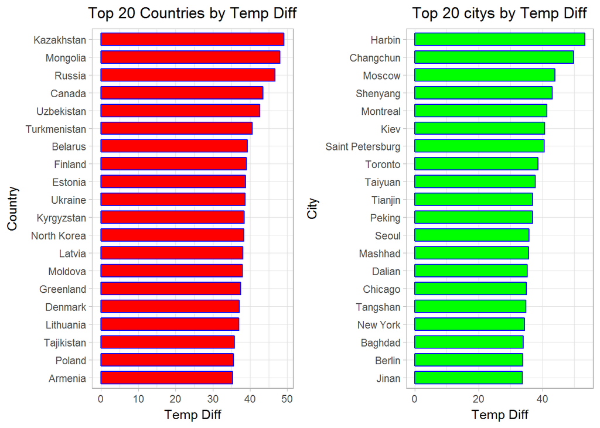

```r
#plot side byside graphs frm i and iii
require(gridExtra)
grid.arrange(i, iii, ncol=2)
```

# Question 05 (15 points)

Write a function in `R or Python` that converts temperature to either Fahrenheit or Celsius. Your function definition should be as follows â

Inputs:

```
Temp_val = Int or list of temperature values to be converted.

        Convert_to = Str.  "F" to convert to Fahrenheit or "C" to convert to Celsius. Raise error
                               if the strings do not match specified input.
```

Output:

```
Int or list of converted temperature values with temperature unit.
```

```r
TempConverter<-function(Temp_val , convert_to){
  #make sure all inputs passed are numeric
   tryCatch({as.numeric(Temp_val)
     },
   error = function(e) {
     print("EXCEPTION!! Can only convert numeric inputs")})
   #only F or C conversions are supported
   if(convert_to=='F' || convert_to=='C'){
      #from Celsius to Fahrenheit: first multiply by 180/100, then add 32
      if(toupper(convert_to)=='F'){
        print(paste("Converting",paste0(Temp_val," degree Celsius")," to Fahrenheit"))
        return(paste0((Temp_val*(180/100))+32," degree Fahrenheit"))
        }
      #from Fahrenheit to Celsius: first subtract 32, then multiply by 100/180
      if(toupper(convert_to)=='C'){
        print(paste("Converting",paste0(Temp_val," degree Fahrenheit")," to Celsius"))
        return(paste0((Temp_val-32)*(100/180)," degree Celsius"))
        }
   }
   else{
     print("EXCEPTION!! Only an 'F'to convert to Fahrenheit or 'C' to convert to Celsius are supported")
   }
}

#Testing the Function
TempConverter((68.5), 'F')
```

```
## [1] "Converting 68.5 degree Celsius  to Fahrenheit"
```

```
## [1] "155.3 degree Fahrenheit"
```

```r
TempConverter(c(10, 0, 23), 'C')
```

```
## [1] "Converting 10 degree Fahrenheit  to Celsius"
## [2] "Converting 0 degree Fahrenheit  to Celsius"
## [3] "Converting 23 degree Fahrenheit  to Celsius"
```

```
## [1] "-12.2222222222222 degree Celsius" "-17.7777777777778 degree Celsius"
## [3] "-5 degree Celsius"
```

```r
TempConverter(c(10, 0, 23), 'F')
```

```
## [1] "Converting 10 degree Celsius  to Fahrenheit"
## [2] "Converting 0 degree Celsius  to Fahrenheit"
## [3] "Converting 23 degree Celsius  to Fahrenheit"
```

```
## [1] "50 degree Fahrenheit"   "32 degree Fahrenheit"
## [3] "73.4 degree Fahrenheit"
```

```r
TempConverter(32, 'C')
```

```
## [1] "Converting 32 degree Fahrenheit  to Celsius"
```

```
## [1] "0 degree Celsius"
```

```r
TempConverter(0, 'X')
```

```
## [1] "EXCEPTION!! Only an 'F'to convert to Fahrenheit or 'C' to convert to Celsius are supported"
```